# Python Cheatsheet

## Contents

1. Syntax and whitespace
2. Comments
3. Numbers and operations
4. String manipulation
5. Lists, tuples, and dictionaries
6. JSON
7. Loops
8. File handling
9. Functions
10. Working with datetime
11. NumPy
12. Pandas

To run a cell, press **Shift+Enter** or click **Run** at the top of the page.

## 1. Syntax and whitespace

Python uses indented space to indicate the level of statements. The following cell is an example where '**if**' and '**else**' are in same level, while '**print**' is separated by space to a different level. Spacing should be the same for items that are on the same level.

```python
student_number = input("Enter your student number:")
if student_number != 0:
    print("Welcome student {}".format(student_number))
else:
    print("Try again!")
```

```
Enter your student number:42
Welcome student 42
```

## 2. Comments

In Python, comments start with hash '#' and extend to the end of the line. '#' can be at the begining of the line or after code.

```python
# This is code to print hello world!

print("Hello world!") # Print statement for hello world
print("# is not a comment in this case")
```

```
Hello world!
# is not a comment in this case
```

## 3. Numbers and operations

Like with other programming languages, there are four types of numbers:

- Integers (e.g., 1, 20, 45, 1000) indicated by *int*
- Floating point numbers (e.g., 1.25, 20.35, 1000.00) indicated by *float*
- Long integers
- Complex numbers (e.g., x+2y where x is known)

| Operation | Result |
| --- | --- |
| x + y | Sum of x and y |
| x - y | Difference of x and y |
| x * y | Product of x and y |
| x / y | Quotient of x and y |
| x // y | Quotient of x and y (floored) |
| x % y | Remainder of x / y |
| abs(x) | Absolute value of x |
| int(x) | x converted to integer |
| long(x) | x converted to long integer |
| float(x) | x converted to floating point |
| pow(x, y) | x to the power y |
| x ** y | x to the power y |

```python
# Number examples
a = 5 + 8
print("Sum of int numbers: {} and number format is {}".format(a, type(a)))

b = 5 + 2.3
print ("Sum of int and {} and number format is {}".format(b, type(b)))
```

```
Sum of int numbers: 13 and number format is <class 'int'>
Sum of int and 7.3 and number format is <class 'float'>
```

## 4. String manipulation

Python has rich features like other programming languages for string manipulation.

```python
# Store strings in a variable
test_word = "hello world to everyone"

# Print the test_word value
print(test_word)

# Use [] to access the character of the string. The first character is indicated by '0'.
print(test_word[0])

# Use the len() function to find the length of the string
print(len(test_word))

# Some examples of finding in strings
print(test_word.count('l')) # Count number of times l repeats in the string
print(test_word.find("o")) # Find letter 'o' in the string. Returns the position of first match.
print(test_word.count(' ')) # Count number of spaces in the string
print(test_word.upper()) # Change the string to uppercase
print(test_word.lower()) # Change the string to lowercase
print(test_word.replace("everyone","you")) # Replace word "everyone" with "you"
print(test_word.title()) # Change string to title format
print(test_word + "!!!") # Concatenate strings
print(":".join(test_word)) # Add ":" between each character
print("".join(reversed(test_word))) # Reverse the string
```

```
hello world to everyone
h
23
3
4
3
HELLO WORLD TO EVERYONE
hello world to everyone
hello world to you
Hello World To Everyone
hello world to everyone!!!
h:e:l:l:o: :w:o:r:l:d: :t:o: :e:v:e:r:y:o:n:e
enoyreve ot dlrow olleh
```

## 5. Lists, tuples, and dictionaries

Python supports data types lists, tuples, dictionaries, and arrays.

### Lists

A list is created by placing all the items (elements) inside square brackets [ ] separated by commas. A list can have any number of items, and they may be of different types (integer, float, strings, etc.).

```python
# A Python list is similar to an array. You can create an empty list too.

my_list = []

first_list = [3, 5, 7, 10]
second_list = [1, 'python', 3]
```

```python
# Nest multiple lists
nested_list = [first_list, second_list]
nested_list
```

```
[[3, 5, 7, 10], [1, 'python', 3]]
```

```python
# Combine multiple lists
combined_list = first_list + second_list
combined_list
```

```
[3, 5, 7, 10, 1, 'python', 3]
```

```python
# You can slice a list, just like strings
combined_list[0:3]
```

```
[3, 5, 7]
```

```python
# Append a new entry to the list
combined_list.append(600)
combined_list
```

```
[3, 5, 7, 10, 1, 'python', 3, 600]
```

```python
# Remove the last entry from the list
combined_list.pop()
```

```
600
```

```python
# Iterate the list
for item in combined_list:
    print(item)
```

```
3
5
7
10
1
python
3
```

### Tuples

A tuple is similar to a list, but you use them with parentheses ( ) instead of square brackets. The main difference is that a tuple is immutable, while a list is mutable.

```python
my_tuple = (1, 2, 3, 4, 5)
my_tuple[1:4]
```

```
(2, 3, 4)
```

### Dictionaries

A dictionary is also known as an associative array. A dictionary consists of a collection of key-value pairs. Each key-value pair maps the key to its associated value.

```python
desk_location = {'jack': 123, 'joe': 234, 'hary': 543}
desk_location['jack']
```

```
123
```

## 6. JSON

JSON is text writen in JavaScript Object Notation. Python has a built-in package called `json` that can be used to work with JSON data.

```python
import json

# Sample JSON data
x = '{"first_name":"Jane", "last_name":"Doe", "age":25, "city":"Chicago"}'

# Read JSON data
y = json.loads(x)

# Print the output, which is similar to a dictonary
print("Employee name is "+ y["first_name"] + " " + y["last_name"])
```

```
Employee name is Jane Doe
```

## 7. Loops

**If, Else, ElIf loop**: Python supports conditional statements like any other programming language. Python relies on indentation (whitespace at the begining of the line) to define the scope of the code.

```python
a = 22
b = 33
c = 100

# if ... else example
if a > b:
    print("a is greater than b")
else:
    print("b is greater than a")


# if .. else .. elif example

if a > b:
    print("a is greater than b")
elif b > c:
    print("b is greater than c")
else:
    print("b is greater than a and c is greater than b")
```

```
b is greater than a
b is greater than a and c is greater than b
```

**While loop:** Processes a set of statements as long as the condition is true

```python
# Sample while example
i = 1
while i < 10:
    print("count is " + str(i))
    i += 1

print("="*10)

# Continue to next iteration if x is 2. Finally, print message once the condition is false.

x = 0
while x < 5:
    x += 1
    if x == 2:
        continue
    print(x)
else:
    print("x is no longer less than 5")
```

```
count is 1
count is 2
count is 3
count is 4
count is 5
count is 6
count is 7
count is 8
count is 9
==========
1
3
4
5
x is no longer less than 5
```

**For loop:** A `For` loop is more like an iterator in Python. A `For` loop is used for iterating over a sequence (list, tuple, dictionay, set, string, or range).

```python
# Sample for loop examples
fruits = ["orange", "banana", "apple", "grape", "cherry"]
for fruit in fruits:
    print(fruit)

print("\n")
print("="*10)
print("\n")

# Iterating range
for x in range(1, 10, 2):
    print(x)
else:
    print("task complete")

print("\n")
print("="*10)
print("\n")

# Iterating multiple lists
traffic_lights = ["red", "yellow", "green"]
action = ["stop", "slow down", "go"]

for light in traffic_lights:
    for task in action:
        print(light, task)
```

```
orange
banana
apple
grape
cherry


==========


1
3
5
7
9
task complete


==========


red stop
red slow down
red go
yellow stop
yellow slow down
yellow go
green stop
green slow down
green go
```

## 8. File handling

The key function for working with files in Python is the `open()` function. The `open()` function takes two parameters: filename and mode.

There are four different methods (modes) for opening a file:

- "r" - Read
- "a" - Append
- "w" - Write
- "x" - Create

In addition, you can specify if the file should be handled in binary or text mode.

- "t" - Text
- "b" - Binary

```python
# Let's create a test text file
!echo "This is a test file with text in it. This is the first line." > test.txt
!echo "This is the second line." >> test.txt
!echo "This is the third line." >> test.txt
```

```python
# Read file
file = open('test.txt', 'r')
print(file.read())
file.close()

print("\n")
print("="*10)
print("\n")

# Read first 10 characters of the file
file = open('test.txt', 'r')
print(file.read(10))
file.close()

print("\n")
print("="*10)
print("\n")

# Read line from the file

file = open('test.txt', 'r')
print(file.readline())
file.close()
```

```
This is a test file with text in it. This is the first line.
This is the second line.
This is the third line.



==========


This is a


==========


This is a test file with text in it. This is the first line.
```

```python
# Create new file

file = open('test2.txt', 'w')
file.write("This is content in the new test2 file.")
file.close()

# Read the content of the new file
file = open('test2.txt', 'r')
print(file.read())
file.close()
```

```
This is content in the new test2 file.
```

```python
# Update file
file = open('test2.txt', 'a')
file.write("\nThis is additional content in the new file.")
file.close()

# Read the content of the new file
file = open('test2.txt', 'r')
print(file.read())
file.close()
```

```
This is content in the new test2 file.
This is additional content in the new file.
```

```python
# Delete file
import os
file_names = ["test.txt", "test2.txt"]
for item in file_names:
    if os.path.exists(item):
        os.remove(item)
        print(f"File {item} removed successfully!")
    else:
        print(f"{item} file does not exist.")
```

```
File test.txt removed successfully!
File test2.txt removed successfully!
```

## 9. Functions

A function is a block of code that runs when it is called. You can pass data, or *parameters*, into the function. In Python, a function is defined by `def`.

```python
# Defining a function
def new_funct():
    print("A simple function")

# Calling the function
new_funct()
```

```
A simple function
```

```python
# Sample fuction with parameters

def param_funct(first_name):
    print(f"Employee name is {first_name}.")

param_funct("Harry")
param_funct("Larry")
param_funct("Shally")
```

```
Employee name is Harry.
Employee name is Larry.
Employee name is Shally.
```

**Anonymous functions (lambda):** A lambda is a small anonymous function. A lambda function can take any number of arguments but only one expression.

```python
# Sample lambda example
x = lambda y: y + 100
print(x(15))

print("\n")
print("="*10)
print("\n")

x = lambda a, b: a*b/100
print(x(2,4))
```

```
115


==========


0.08
```

## 10. Working with datetime

A `datetime` module in Python can be used to work with date objects.

```python
import datetime

x = datetime.datetime.now()

print(x)
print(x.year)
print(x.strftime("%A"))
print(x.strftime("%B"))
print(x.strftime("%d"))
print(x.strftime("%H:%M:%S %p"))
```

```
2020-11-03 12:51:16.738996
2020
Tuesday
November
03
12:51:16 PM
```

## 11. NumPy

NumPy is the fundamental package for scientific computing with Python. Among other things, it contains:

- Powerful N-dimensional array object
- Sophisticated (broadcasting) functions
- Tools for integrating C/C++ and Fortran code
- Useful linear algebra, Fourier transform, and random number capabilities

```python
# Install NumPy using pip
!pip install numpy
```

```python
# Import NumPy module
import numpy as np
```

### Inspecting your array

```python
# Create array
a = np.arange(15).reshape(3, 5) # Create array with range 0-14 in 3 by 5 dimension
b = np.zeros((3,5)) # Create array with zeroes
c = np.ones( (2,3,4), dtype=np.int16 ) # Createarray with ones and defining data types
d = np.ones((3,5))
```

```python
a.shape # Array dimension
```

```
(3, 5)
```

```python
len(b)# Length of array
```

```
3
```

```python
c.ndim # Number of array dimensions
```

```
3
```

```python
a.size # Number of array elements
```

```
15
```

```python
b.dtype # Data type of array elements
```

```
dtype('float64')
```

```python
c.dtype.name # Name of data type
```

```
'int16'
```

```python
c.astype(float) # Convert an array type to a different type
```

```
array([[[1., 1., 1., 1.],
        [1., 1., 1., 1.],
        [1., 1., 1., 1.]],

       [[1., 1., 1., 1.],
        [1., 1., 1., 1.],
        [1., 1., 1., 1.]]])
```

### Basic math operations

```python
# Create array
a = np.arange(15).reshape(3, 5) # Create array with range 0-14 in 3 by 5 dimension
b = np.zeros((3,5)) # Create array with zeroes
c = np.ones( (2,3,4), dtype=np.int16 ) # Createarray with ones and defining data types
d = np.ones((3,5))
```

```python
np.add(a,b) # Addition
```

```
array([[ 0.,  1.,  2.,  3.,  4.],
       [ 5.,  6.,  7.,  8.,  9.],
       [10., 11., 12., 13., 14.]])
```

```python
np.subtract(a,b) # Substraction
```

```
array([[ 0.,  1.,  2.,  3.,  4.],
       [ 5.,  6.,  7.,  8.,  9.],
       [10., 11., 12., 13., 14.]])
```

```python
np.divide(a,d) # Division
```

```
array([[ 0.,  1.,  2.,  3.,  4.],
       [ 5.,  6.,  7.,  8.,  9.],
       [10., 11., 12., 13., 14.]])
```

```python
np.multiply(a,d) # Multiplication
```

```
array([[ 0.,  1.,  2.,  3.,  4.],
       [ 5.,  6.,  7.,  8.,  9.],
       [10., 11., 12., 13., 14.]])
```

```python
np.array_equal(a,b) # Comparison - arraywise
```

```
False
```

### Aggregate functions

```python
# Create array
a = np.arange(15).reshape(3, 5) # Create array with range 0-14 in 3 by 5 dimension
b = np.zeros((3,5)) # Create array with zeroes
c = np.ones( (2,3,4), dtype=np.int16 ) # Createarray with ones and defining data types
d = np.ones((3,5))
```

```python
a.sum() # Array-wise sum
```

```
105
```

```python
a.min() # Array-wise min value
```

```
0
```

```python
a.mean() # Array-wise mean
```

```
7.0
```

```python
a.max(axis=0) # Max value of array row
```

```
array([10, 11, 12, 13, 14])
```

```python
np.std(a) # Standard deviation
```

```
4.320493798938574
```

### Subsetting, slicing, and indexing

```python
# Create array
a = np.arange(15).reshape(3, 5) # Create array with range 0-14 in 3 by 5 dimension
b = np.zeros((3,5)) # Create array with zeroes
c = np.ones( (2,3,4), dtype=np.int16 ) # Createarray with ones and defining data types
d = np.ones((3,5))
```

```python
a[1,2] # Select element of row 1 and column 2
```

```
7
```

```python
a[0:2] # Select items on index 0 and 1
```

```
array([[0, 1, 2, 3, 4],
       [5, 6, 7, 8, 9]])
```

```python
a[:1] # Select all items at row 0
```

```
array([[0, 1, 2, 3, 4]])
```

```python
a[-1:] # Select all items from last row
```

```
array([[10, 11, 12, 13, 14]])
```

```python
a[a<2] # Select elements from 'a' that are less than 2
```

```
array([0, 1])
```

### Array manipulation

```python
# Create array
a = np.arange(15).reshape(3, 5) # Create array with range 0-14 in 3 by 5 dimension
b = np.zeros((3,5)) # Create array with zeroes
c = np.ones( (2,3,4), dtype=np.int16 ) # Createarray with ones and defining data types
d = np.ones((3,5))
```

```python
np.transpose(a) # Transpose array 'a'
```

```
array([[ 0,  5, 10],
       [ 1,  6, 11],
       [ 2,  7, 12],
       [ 3,  8, 13],
       [ 4,  9, 14]])
```

```python
a.ravel() # Flatten the array
```

```
array([ 0,  1,  2,  3,  4,  5,  6,  7,  8,  9, 10, 11, 12, 13, 14])
```

```python
a.reshape(5,-2) # Reshape but don't change the data
```

```
array([[ 0,  1,  2],
       [ 3,  4,  5],
       [ 6,  7,  8],
       [ 9, 10, 11],
       [12, 13, 14]])
```

```python
np.append(a,b) # Append items to the array
```

```
array([ 0.,  1.,  2.,  3.,  4.,  5.,  6.,  7.,  8.,  9., 10., 11., 12.,
       13., 14.,  0.,  0.,  0.,  0.,  0.,  0.,  0.,  0.,  0.,  0.,  0.,
        0.,  0.,  0.,  0.])
```

```python
np.concatenate((a,d), axis=0) # Concatenate arrays
```

```
array([[ 0.,  1.,  2.,  3.,  4.],
       [ 5.,  6.,  7.,  8.,  9.],
       [10., 11., 12., 13., 14.],
       [ 1.,  1.,  1.,  1.,  1.],
       [ 1.,  1.,  1.,  1.,  1.],
       [ 1.,  1.,  1.,  1.,  1.]])
```

```python
np.vsplit(a,3) # Split array vertically at 3rd index
```

```
[array([[0, 1, 2, 3, 4]]),
 array([[5, 6, 7, 8, 9]]),
 array([[10, 11, 12, 13, 14]])]
```

```python
np.hsplit(a,5) # Split array horizontally at 5th index
```

```
[array([[ 0],
        [ 5],
        [10]]),
 array([[ 1],
        [ 6],
        [11]]),
 array([[ 2],
        [ 7],
        [12]]),
 array([[ 3],
        [ 8],
        [13]]),
 array([[ 4],
        [ 9],
        [14]])]
```

## Pandas

Pandas is an open source, BSD-licensed library providing high-performance, easy-to-use data structures and data analysis tools for the Python programming language.

Pandas DataFrames are the most widely used in-memory representation of complex data collections within Python.

```python
# Install pandas, xlrd, and openpyxl using pip
!pip install pandas
!pip install xlrd openpyxl
```

```python
# Import NumPy and Pandas modules
import numpy as np
import pandas as pd
```

```python
# Sample dataframe df
df = pd.DataFrame({'num_legs': [2, 4, np.nan, 0],
                   'num_wings': [2, 0, 0, 0],
                   'num_specimen_seen': [10, np.nan, 1, 8]},
                   index=['falcon', 'dog', 'spider', 'fish'])
df # Display dataframe df
```

|  | num_legs | num_wings | num_specimen_seen |
| --- | --- | --- | --- |
| falcon | 2.0 | 2 | 10.0 |
| dog | 4.0 | 0 | NaN |
| spider | NaN | 0 | 1.0 |
| fish | 0.0 | 0 | 8.0 |

```python
# Another sample dataframe df1 - using NumPy array with datetime index and labeled column
df1 = pd.date_range('20130101', periods=6)
df1 = pd.DataFrame(np.random.randn(6, 4), index=df1, columns=list('ABCD'))
df1 # Display dataframe df1
```

|  | A | B | C | D |
| --- | --- | --- | --- | --- |
| 2013-01-01 | 1.070100 | -0.343427 | -0.447455 | 0.655999 |
| 2013-01-02 | -0.320919 | 0.553324 | 0.107834 | 0.425223 |
| 2013-01-03 | -0.775491 | 0.286976 | -0.007494 | -0.521515 |
| 2013-01-04 | 0.540137 | 1.468475 | 0.859511 | 0.129053 |
| 2013-01-05 | -0.510042 | 0.558653 | -0.703415 | 0.261367 |
| 2013-01-06 | -0.850282 | 0.596008 | 2.126942 | -1.342764 |

### Viewing data

```python
df1 = pd.date_range('20130101', periods=6)
df1 = pd.DataFrame(np.random.randn(6, 4), index=df1, columns=list('ABCD'))
```

```python
df1.head(2) # View top data
```

|  | A | B | C | D |
| --- | --- | --- | --- | --- |
| 2013-01-01 | -1.110730 | 1.086119 | -0.004901 | 0.821143 |
| 2013-01-02 | 0.106526 | -0.397127 | -0.711641 | -0.522394 |

```python
df1.tail(2) # View bottom data
```

|  | A | B | C | D |
| --- | --- | --- | --- | --- |
| 2013-01-05 | -0.289355 | 0.157145 | -0.113453 | -1.551845 |
| 2013-01-06 | -0.112429 | -0.273278 | 0.788012 | -0.116429 |

```python
df1.index # Display index column
```

```
DatetimeIndex(['2013-01-01', '2013-01-02', '2013-01-03', '2013-01-04',
               '2013-01-05', '2013-01-06'],
              dtype='datetime64[ns]', freq='D')
```

```python
df1.dtypes # Inspect datatypes
```

```
A    float64
B    float64
C    float64
D    float64
dtype: object
```

```python
df1.describe() # Display quick statistics summary of data
```

|  | A | B | C | D |
| --- | --- | --- | --- | --- |
| count | 6.000000 | 6.000000 | 6.000000 | 6.000000 |
| mean | -0.480828 | -0.072645 | -0.050123 | -0.408734 |
| std | 0.766396 | 0.628079 | 0.709708 | 0.841850 |
| min | -1.711308 | -0.675498 | -0.953917 | -1.551845 |
| 25% | -0.905386 | -0.381154 | -0.562094 | -0.944266 |
| 50% | -0.200892 | -0.303256 | -0.059177 | -0.319411 |
| 75% | 0.051787 | 0.049539 | 0.520148 | -0.027601 |
| max | 0.232328 | 1.086119 | 0.788012 | 0.821143 |

### Subsetting, slicing, and indexing

```python
df1 = pd.date_range('20130101', periods=6)
df1 = pd.DataFrame(np.random.randn(6, 4), index=df1, columns=list('ABCD'))
```

```python
df1.T # Transpose data
```

|  | 2013-01-01 | 2013-01-02 | 2013-01-03 | 2013-01-04 | 2013-01-05 | 2013-01-06 |
| --- | --- | --- | --- | --- | --- | --- |
| A | 0.205134 | -1.303991 | -0.836485 | -0.644298 | -0.345657 | 0.319633 |
| B | -1.319794 | -0.729071 | 0.434638 | 0.991025 | -0.501524 | 1.688893 |
| C | 1.507017 | -2.575001 | 1.851609 | -0.813386 | -1.048465 | 0.141670 |
| D | -1.221931 | -1.312567 | 0.842371 | 0.927111 | -0.624740 | -0.702711 |

```python
df1.sort_index(axis=1, ascending=False) # Sort by an axis
```

|  | D | C | B | A |
| --- | --- | --- | --- | --- |
| 2013-01-01 | -1.221931 | 1.507017 | -1.319794 | 0.205134 |
| 2013-01-02 | -1.312567 | -2.575001 | -0.729071 | -1.303991 |
| 2013-01-03 | 0.842371 | 1.851609 | 0.434638 | -0.836485 |
| 2013-01-04 | 0.927111 | -0.813386 | 0.991025 | -0.644298 |
| 2013-01-05 | -0.624740 | -1.048465 | -0.501524 | -0.345657 |
| 2013-01-06 | -0.702711 | 0.141670 | 1.688893 | 0.319633 |

```python
df1.sort_values(by='B') # Sort by values
```

|  | A | B | C | D |
| --- | --- | --- | --- | --- |
| 2013-01-01 | 0.205134 | -1.319794 | 1.507017 | -1.221931 |
| 2013-01-02 | -1.303991 | -0.729071 | -2.575001 | -1.312567 |
| 2013-01-05 | -0.345657 | -0.501524 | -1.048465 | -0.624740 |
| 2013-01-03 | -0.836485 | 0.434638 | 1.851609 | 0.842371 |
| 2013-01-04 | -0.644298 | 0.991025 | -0.813386 | 0.927111 |
| 2013-01-06 | 0.319633 | 1.688893 | 0.141670 | -0.702711 |

```python
df1['A'] # Select column A
```

```
2013-01-01    0.205134
2013-01-02   -1.303991
2013-01-03   -0.836485
2013-01-04   -0.644298
2013-01-05   -0.345657
2013-01-06    0.319633
Freq: D, Name: A, dtype: float64
```

```python
df1[0:3] # Select index 0 to 2
```

|  | A | B | C | D |
| --- | --- | --- | --- | --- |
| 2013-01-01 | 0.205134 | -1.319794 | 1.507017 | -1.221931 |
| 2013-01-02 | -1.303991 | -0.729071 | -2.575001 | -1.312567 |
| 2013-01-03 | -0.836485 | 0.434638 | 1.851609 | 0.842371 |

```python
df1['20130102':'20130104'] # Select from index matching the values
```

|  | A | B | C | D |
| --- | --- | --- | --- | --- |
| 2013-01-02 | -1.303991 | -0.729071 | -2.575001 | -1.312567 |
| 2013-01-03 | -0.836485 | 0.434638 | 1.851609 | 0.842371 |
| 2013-01-04 | -0.644298 | 0.991025 | -0.813386 | 0.927111 |

```python
df1.loc[:, ['A', 'B']] # Select on a multi-axis by label
```

|  | A | B |
| --- | --- | --- |
| 2013-01-01 | 0.205134 | -1.319794 |
| 2013-01-02 | -1.303991 | -0.729071 |
| 2013-01-03 | -0.836485 | 0.434638 |
| 2013-01-04 | -0.644298 | 0.991025 |
| 2013-01-05 | -0.345657 | -0.501524 |
| 2013-01-06 | 0.319633 | 1.688893 |

```python
df1.iloc[3] # Select via the position of the passed integers
```

```
A   -0.644298
B    0.991025
C   -0.813386
D    0.927111
Name: 2013-01-04 00:00:00, dtype: float64
```

```python
df1[df1 > 0] # Select values from a DataFrame where a boolean condition is met
```

|  | A | B | C | D |
| --- | --- | --- | --- | --- |
| 2013-01-01 | 0.205134 | NaN | 1.507017 | NaN |
| 2013-01-02 | NaN | NaN | NaN | NaN |
| 2013-01-03 | NaN | 0.434638 | 1.851609 | 0.842371 |
| 2013-01-04 | NaN | 0.991025 | NaN | 0.927111 |
| 2013-01-05 | NaN | NaN | NaN | NaN |
| 2013-01-06 | 0.319633 | 1.688893 | 0.141670 | NaN |

```python
df2 = df1.copy() # Copy the df1 dataset to df2
df2['E'] = ['one', 'one', 'two', 'three', 'four', 'three'] # Add column E with value
df2[df2['E'].isin(['two', 'four'])] # Use isin method for filtering
```

|  | A | B | C | D | E |
| --- | --- | --- | --- | --- | --- |
| 2013-01-03 | -0.836485 | 0.434638 | 1.851609 | 0.842371 | two |
| 2013-01-05 | -0.345657 | -0.501524 | -1.048465 | -0.624740 | four |

### Missing data

Pandas primarily uses the value `np.nan` to represent missing data. It is not included in computations by default.

```python
df = pd.DataFrame({'num_legs': [2, 4, np.nan, 0],
                   'num_wings': [2, 0, 0, 0],
                   'num_specimen_seen': [10, np.nan, 1, 8]},
                   index=['falcon', 'dog', 'spider', 'fish'])
```

```python
df.dropna(how='any') # Drop any rows that have missing data
```

|  | num_legs | num_wings | num_specimen_seen |
| --- | --- | --- | --- |
| falcon | 2.0 | 2 | 10.0 |
| fish | 0.0 | 0 | 8.0 |

```python
df.dropna(how='any', axis=1) # Drop any columns that have missing data
```

|  | num_wings |
| --- | --- |
| falcon | 2 |
| dog | 0 |
| spider | 0 |
| fish | 0 |

```python
df.fillna(value=5) # Fill missing data with value 5
```

|  | num_legs | num_wings | num_specimen_seen |
| --- | --- | --- | --- |
| falcon | 2.0 | 2 | 10.0 |
| dog | 4.0 | 0 | 5.0 |
| spider | 5.0 | 0 | 1.0 |
| fish | 0.0 | 0 | 8.0 |

```python
pd.isna(df) # To get boolean mask where data is missing
```

|  | num_legs | num_wings | num_specimen_seen |
| --- | --- | --- | --- |
| falcon | False | False | False |
| dog | False | False | True |
| spider | True | False | False |
| fish | False | False | False |

### File handling

```python
df = pd.DataFrame({'num_legs': [2, 4, np.nan, 0],
                   'num_wings': [2, 0, 0, 0],
                   'num_specimen_seen': [10, np.nan, 1, 8]},
                   index=['falcon', 'dog', 'spider', 'fish'])
```

```python
df.to_csv('foo.csv') # Write to CSV file
```

```python
pd.read_csv('foo.csv') # Read from CSV file
```

|  | Unnamed: 0 | num_legs | num_wings | num_specimen_seen |
| --- | --- | --- | --- | --- |
| 0 | falcon | 2.0 | 2 | 10.0 |
| 1 | dog | 4.0 | 0 | NaN |
| 2 | spider | NaN | 0 | 1.0 |
| 3 | fish | 0.0 | 0 | 8.0 |

```python
df.to_excel('foo.xlsx', sheet_name='Sheet1') # Write to Microsoft Excel file
```

```python
pd.read_excel('foo.xlsx', 'Sheet1', index_col=None, na_values=['NA']) # Read from Microsoft Excel file
```

|  | Unnamed: 0 | num_legs | num_wings | num_specimen_seen |
| --- | --- | --- | --- | --- |
| 0 | falcon | 2.0 | 2 | 10.0 |
| 1 | dog | 4.0 | 0 | NaN |
| 2 | spider | NaN | 0 | 1.0 |
| 3 | fish | 0.0 | 0 | 8.0 |

### Plotting

```python
# Install Matplotlib using pip
!pip install matplotlib
```

```python
from matplotlib import pyplot as plt # Import Matplotlib module
```

```python
# Generate random time-series data
ts = pd.Series(np.random.randn(1000),index=pd.date_range('1/1/2000', periods=1000))
ts.head()
```

```
2000-01-01   -0.634952
2000-01-02   -0.400831
2000-01-03   -0.627817
2000-01-04   -1.575074
2000-01-05   -0.925545
Freq: D, dtype: float64
```

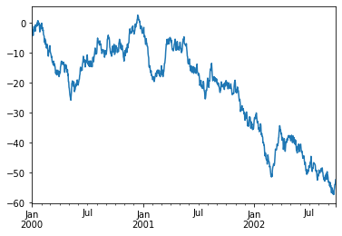

```python
ts = ts.cumsum()
ts.plot() # Plot graph
plt.show()
```

```python
# On a DataFrame, the plot() method is convenient to plot all of the columns with labels
df4 = pd.DataFrame(np.random.randn(1000, 4), index=ts.index,columns=['A', 'B', 'C', 'D'])
df4 = df4.cumsum()
df4.head()
```

|  | A | B | C | D |
| --- | --- | --- | --- | --- |
| 2000-01-01 | 1.081833 | -0.692866 | 1.054972 | -2.092212 |
| 2000-01-02 | 1.442031 | -2.139720 | 3.341366 | -2.561976 |
| 2000-01-03 | -0.331137 | -1.688450 | 4.898932 | -2.258222 |
| 2000-01-04 | -2.274100 | -1.170857 | 4.716548 | -1.560002 |
| 2000-01-05 | -1.310669 | -0.592832 | 4.942299 | -1.347377 |

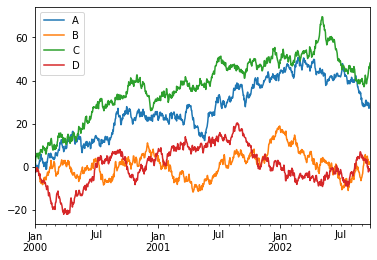

```python
df4.plot()
plt.show()
```